# Fitbit Data Analysis

```r
# Importing the packages
library(tidyverse)
library(ggplot2)
```

```r
# Loading the dataset
daily_activity <- read_csv("fitabase_data/dailyActivity_merged.csv")
```

```r
# Viewing the data
head(daily_activity)
```

| Id | ActivityDate | TotalSteps | TotalDistance | TrackerDistance | LoggedActivitiesDistance | VeryActiveDistance | ModeratelyActiveDistance | LightActiveDistance | SedentaryActiveDistance | VeryActiveMinutes | FairlyActiveMinutes | LightlyActiveMinutes | SedentaryMinutes | Calories |
| --- | --- | --- | --- | --- | --- | --- | --- | --- | --- | --- | --- | --- | --- | --- |
| 1503960366 | 4/12/2016 | 13162 | 8.50 | 8.50 | 0 | 1.88 | 0.55 | 6.06 | 0 | 25 | 13 | 328 | 728 | 1985 |
| 1503960366 | 4/13/2016 | 10735 | 6.97 | 6.97 | 0 | 1.57 | 0.69 | 4.71 | 0 | 21 | 19 | 217 | 776 | 1797 |
| 1503960366 | 4/14/2016 | 10460 | 6.74 | 6.74 | 0 | 2.44 | 0.40 | 3.91 | 0 | 30 | 11 | 181 | 1218 | 1776 |
| 1503960366 | 4/15/2016 | 9762 | 6.28 | 6.28 | 0 | 2.14 | 1.26 | 2.83 | 0 | 29 | 34 | 209 | 726 | 1745 |
| 1503960366 | 4/16/2016 | 12669 | 8.16 | 8.16 | 0 | 2.71 | 0.41 | 5.04 | 0 | 36 | 10 | 221 | 773 | 1863 |
| 1503960366 | 4/17/2016 | 9705 | 6.48 | 6.48 | 0 | 3.19 | 0.78 | 2.51 | 0 | 38 | 20 | 164 | 539 | 1728 |

```r
# Getting the column names
colnames(daily_activity)
```

```
 [1] "Id"
 [2] "ActivityDate"
 [3] "TotalSteps"
 [4] "TotalDistance"
 [5] "TrackerDistance"
 [6] "LoggedActivitiesDistance"
 [7] "VeryActiveDistance"
 [8] "ModeratelyActiveDistance"
 [9] "LightActiveDistance"
[10] "SedentaryActiveDistance"
[11] "VeryActiveMinutes"
[12] "FairlyActiveMinutes"
[13] "LightlyActiveMinutes"
[14] "SedentaryMinutes"
[15] "Calories"
```

```r
# Inspecting the structure of data
str(daily_activity)
```

```
spec_tbl_df [940 x 15] (S3: spec_tbl_df/tbl_df/tbl/data.frame)
 $ Id                      : num [1:940] 1.5e+09 1.5e+09 1.5e+09 1.5e+09 1.5e+09 ...
 $ ActivityDate            : chr [1:940] "4/12/2016" "4/13/2016" "4/14/2016" "4/15/2016" ...
 $ TotalSteps              : num [1:940] 13162 10735 10460 9762 12669 ...
 $ TotalDistance           : num [1:940] 8.5 6.97 6.74 6.28 8.16 ...
 $ TrackerDistance         : num [1:940] 8.5 6.97 6.74 6.28 8.16 ...
 $ LoggedActivitiesDistance: num [1:940] 0 0 0 0 0 0 0 0 0 0 ...
 $ VeryActiveDistance      : num [1:940] 1.88 1.57 2.44 2.14 2.71 ...
 $ ModeratelyActiveDistance: num [1:940] 0.55 0.69 0.4 1.26 0.41 ...
 $ LightActiveDistance     : num [1:940] 6.06 4.71 3.91 2.83 5.04 ...
 $ SedentaryActiveDistance : num [1:940] 0 0 0 0 0 0 0 0 0 0 ...
 $ VeryActiveMinutes       : num [1:940] 25 21 30 29 36 38 42 50 28 19 ...
 $ FairlyActiveMinutes     : num [1:940] 13 19 11 34 10 20 16 31 12 8 ...
 $ LightlyActiveMinutes    : num [1:940] 328 217 181 209 221 164 233 264 205 211 ...
 $ SedentaryMinutes        : num [1:940] 728 776 1218 726 773 ...
 $ Calories                : num [1:940] 1985 1797 1776 1745 1863 ...
 - attr(*, "spec")=
  .. cols(
  ..   Id = col_double(),
  ..   ActivityDate = col_character(),
  ..   TotalSteps = col_double(),
  ..   TotalDistance = col_double(),
  ..   TrackerDistance = col_double(),
  ..   LoggedActivitiesDistance = col_double(),
  ..   VeryActiveDistance = col_double(),
  ..   ModeratelyActiveDistance = col_double(),
  ..   LightActiveDistance = col_double(),
  ..   SedentaryActiveDistance = col_double(),
  ..   VeryActiveMinutes = col_double(),
  ..   FairlyActiveMinutes = col_double(),
  ..   LightlyActiveMinutes = col_double(),
  ..   SedentaryMinutes = col_double(),
  ..   Calories = col_double()
  .. )
 - attr(*, "problems")=<externalptr>
```

```r
# Finding number of unique participants in the dataset
n_distinct(daily_activity$Id)
```

```
[1] 33
```

```r
# Getting quick summary of data
daily_activity %>%
  select(TotalSteps, TotalDistance, SedentaryMinutes, Calories) %>%
  summary()
```

```
   TotalSteps    TotalDistance    SedentaryMinutes
 Min.   :    0   Min.   : 0.000   Min.   :   0.0
 1st Qu.: 3790   1st Qu.: 2.620   1st Qu.: 729.8
 Median : 7406   Median : 5.245   Median :1057.5
 Mean   : 7638   Mean   : 5.490   Mean   : 991.2
 3rd Qu.:10727   3rd Qu.: 7.713   3rd Qu.:1229.5
 Max.   :36019   Max.   :28.030   Max.   :1440.0
    Calories
 Min.   :   0
 1st Qu.:1828
 Median :2134
 Mean   :2304
 3rd Qu.:2793
 Max.   :4900
```

By this we can see that each of the four variables have Min. value of 0, this could mean that the tracker was off at time during the data collection.  
The average total steps is 7638. Average total distance is 5.490 miles which is 8.83 km, this could mean that the participants were mostly active. Average sedentary minutes is 991.2 i.e. 16.51 hour.

Average sedentary minutes doesn’t agree with the average total distance, this could mean that the data has outliers.

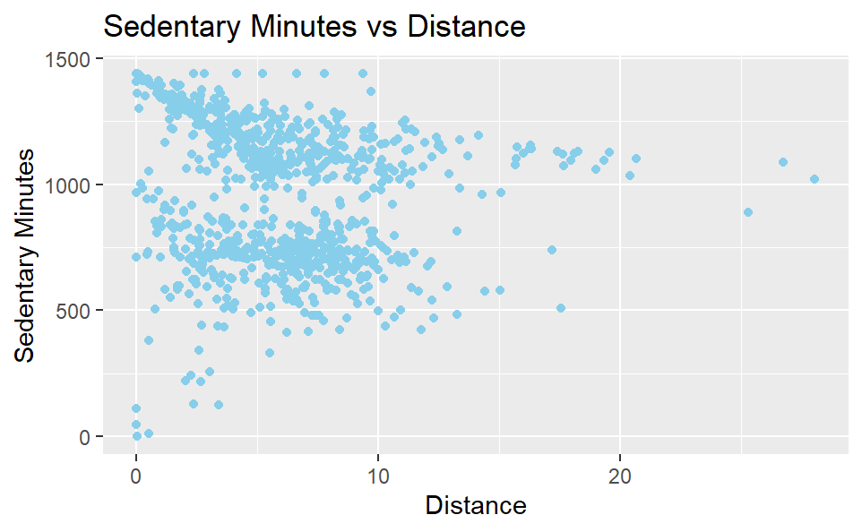

```r
# Plotting total distance vs sedentary minutes
ggplot(data = daily_activity) +
  geom_point(mapping = aes(x = TotalDistance, y = SedentaryMinutes), color= "skyblue") +
  labs(title = "Sedentary Minutes vs Distance", y = "Sedentary Minutes", x = "Distance")
```

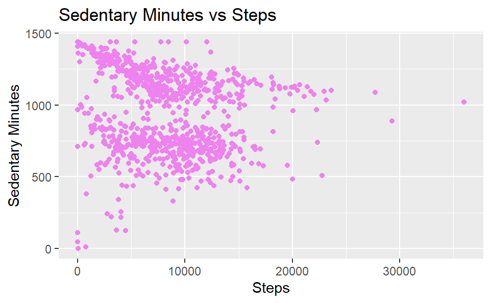

```r
# To investigate the relationship between Sedentary minutes and total steps. plotting a chart.
ggplot(data = daily_activity) +
  geom_point(mapping = aes(x = TotalSteps, y = SedentaryMinutes), color = "violet") +
  labs(title = "Sedentary Minutes vs Steps", x = "Steps", y = "Sedentary Minutes")
```